# Chimera-AI Weekly Market Report

2026년 4월 4주차 (04.17~04.24)

저자

Chimera-AI Multi-Agent System

공개

2026년 4월 24일

## Executive Summary

**중요**

**NS Index: 73.5 / 100** — 투자 환경 양호, 반도체 강세 주도. 단, 중동 지정학 리스크 경계 필요.

**경고**

**호르무즈 해협**: 사실상 봉쇄 상태. 한국 선박 약 26척 고립. 정상 통과 수 100척/일 → 거의 0. **30척 미만 — 투자 본격화 신호 미발동.**

이번 주 시장 3대 키워드: **이란 전쟁/호르무즈 위기**, **AI 반도체 슈퍼사이클**, **빅테크 실적 시즌**

## 1 1. NS Index 산출

NS Index는 시장 공포, 변동성, 반도체 업황, 실질금리를 종합한 독자 지표입니다.

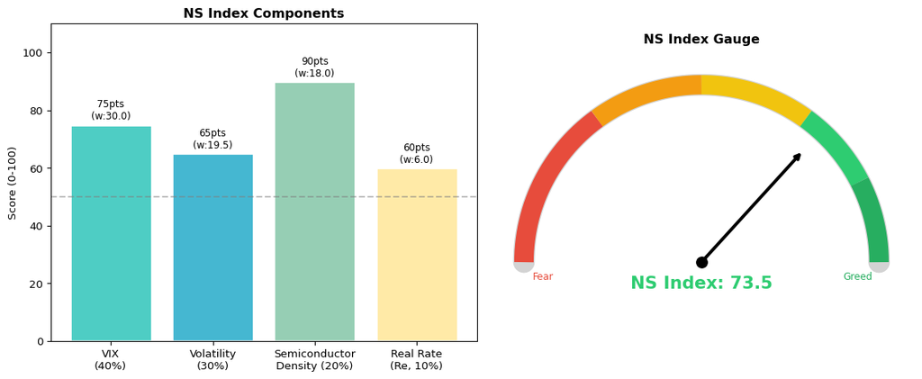

**NS Index 구성 요소:**

- **VIX (40%)**: 19.31 → **75점** (20 이하 안정권, 이란 리스크로 20선 근접)
- **변동성 (30%)**: 주간 S&P -0.41%, KOSPI 신고 후 조정 → **65점**
- **반도체밀도 (20%)**: SOX 10,078, SK하이닉스 사상최대실적, 17일 연속 상승 → **90점**
- **Re 실질금리 (10%)**: 미국 10Y 4.30% - CPI 3.3% = 1.0% → **60점**

> **NS Index = 73.5** — “양호” 구간. 반도체 업황이 강력하게 견인하나, 지정학 리스크와 인플레이션 재상승이 상방 제한 요인.

## 2 2. 글로벌 시장 현황

### 2.1 2.1 미국 증시

- **S&P 500**: 7,108.40 (주간 소폭 조정, 7,000선 안착)
- **NASDAQ**: 24,438.50 (이란 불확실성 -0.89%)
- **Dow Jones**: 49,310.32 (-0.36%)

주 초 3대 지수 사상 최고치 경신 후, 이란 전쟁 리스크 재부상으로 후퇴. S&P500 기업 중 81%가 EPS 서프라이즈 달성.

**주요 실적:**

- 테슬라: EPS $0.41 (예상 상회), 연간 CapEx $50억 추가 → 장외 등락
- 인텔: 예상 상회 + 강한 가이던스 → 장외 +19%
- IBM: 성장 둔화 우려 → -8%
- ServiceNow: 예상 하회 → -18%
- 메타: AI CapEx $1,150~1,350억 예고 (전년 대비 2배)

### 2.2 2.2 한국 증시

- **KOSPI**: 6,417.93 (사상 최고치 경신, 장중 6,557.76 기록)
- **KOSDAQ**: 1,194.67 (+1.73%)

**SK하이닉스 Q1 사상 최대 실적:**

- 매출 52.6조원 (최초 50조 돌파)
- 영업이익 37.6조원, 영업이익률 72% (TSMC 추월)
- HBM, 서버 DRAM, eSSD 등 AI 인프라 수요 폭발

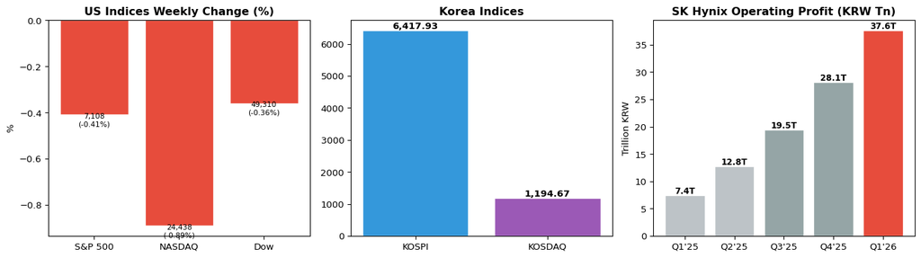

## 3 3. 호르무즈 해협 모니터링

**주의**

**현재 상태: 사실상 봉쇄** (2026.03.02 IRGC 봉쇄 선언 이후)

- 정상 통과: 하루 100척 이상 → **현재 거의 0척** (95% 감소)
- IRGC “톨부스” 시스템: 사전 승인 선박만 통과 허용
- 한국 선박 약 26척 고립, 대체 경로(홍해) 탐색 중
- 4/17 이란 재개방 선언 → 하루 만에 재봉쇄
- 4/22 트럼프 휴전 연장에도 이란 선박 억류 지속
- 전 세계 석유/LNG의 20%가 통과하는 초크포인트

**판정: 30척 미만 — ‘투자 본격화 신호’ 미발동**

> 호르무즈 해협이 정상화(30척 이상/일)되기 전까지는 에너지 공급 리스크가 시장 최대 불확실성 요인으로 지속됩니다.

## 4 4. 투자자 센티멘트

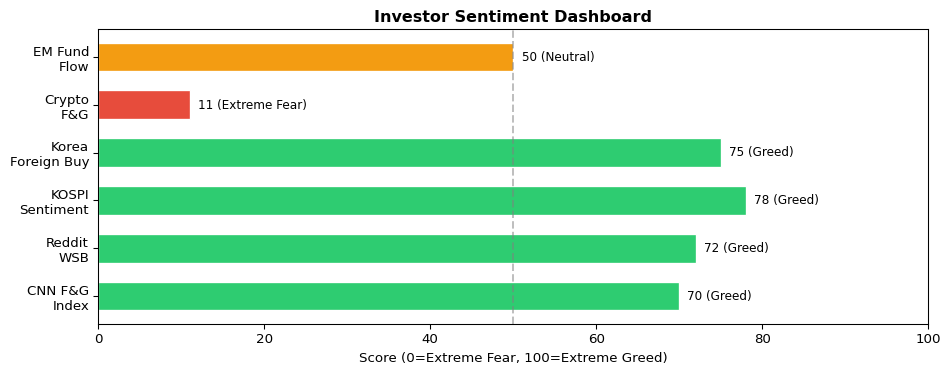

**종합 센티멘트: 탐욕 (Greed)**

- CNN Fear & Greed: **70** (1개월 전 15 극도의 공포에서 급반전)
- WSB: 강세 우세, AI/우주 테마 FOMO
- KOSPI: 외국인 +1.75조 순매수, 개인 -2.36조 차익실현 (과열 신호)
- 암호화폐 F&G: **11** (극도의 공포 — 위험자산 괴리)

## 5 5. 포트폴리오 시사점

**노트**

**운용 자산**: 퇴직연금(한투DC) 3.45억 + 개인연금(삼성) 1.24억 = **총 4.69억원**

### 5.1 5.1 현재 환경 평가

- **반도체**: 슈퍼사이클 진행 중 (SK하이닉스 OPM 72%) → 비중 유지/소폭 확대
- **미국 증시**: S&P 7,100 신고점, 실적 시즌 양호 → 비중 유지
- **에너지**: WTI $96, 호르무즈 봉쇄 → 인플레 리스크 → 에너지주 비중 점검
- **금리**: 동결 장기화, 인하 기대 후퇴 → 채권 듀레이션 축소
- **금**: $4,738 고공행진 → 안전자산 헤지 유효

### 5.2 5.2 액션 아이템

1. **반도체 포지션 유지**: SK하이닉스/삼성전자 중심 비중 유지. SOX 17일 연속 상승은 과열 가능성이나 펀더멘탈이 뒷받침
2. **에너지 헤지 고려**: 호르무즈 봉쇄 장기화 시 유가 $100+ 지속 → 에너지 관련 ETF 소량 편입 검토
3. **금 비중 점검**: 지정학 불안 지속 시 골드 ETF 5~10% 유지 유효
4. **단기 과열 경계**: CNN F&G 70, 개인 차익실현 매도 → 신규 진입 시 분할 매수 전략
5. **FOMC 대기**: 4/28~29 FOMC + 빅테크 실적(메타/알파벳/아마존/MS/애플) 확인 후 비중 조정

## 6 6. 주요 거시 데이터

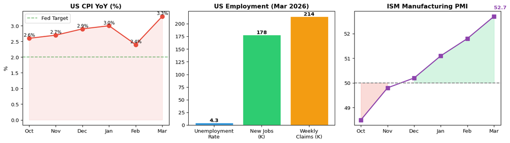

- **CPI**: 3월 3.3% (이란 전쟁發 에너지가 급등 영향, 2월 2.4%에서 급반등)
- **실업률**: 4.3% (견조)
- **ISM 제조업 PMI**: 52.7 (2022년 8월 이후 최고 확장세)
- **비농업고용**: +178K (예상 상회)

## 7 7. 다음 주 관전 포인트

1. **4/28~29 FOMC**: 금리 동결 예상, 성명서 톤 주목 (인플레 재상승 언급 강도)
2. **빅테크 실적**: 메타(4/28), 알파벳/아마존/MS(4/29), 애플(4/30)
3. **호르무즈 해협**: 휴전 협상 진전 여부, 한국 선박 통항 재개 가능성
4. **5/12 미국 4월 CPI**: 유가 급등이 반영될 핵심 데이터
5. **외국인 수급**: KOSPI 신고점 구간 외국인 순매수 지속 여부

**Chimera-AI 판단**

**NS Index 73.5** — 시장은 “양호” 구간이나, 호르무즈 봉쇄 장기화와 인플레 재상승이 최대 리스크. 반도체 슈퍼사이클이 한국 시장의 핵심 동력. 다음 주 FOMC + 빅테크 실적이 방향성 결정의 변곡점.

퇴직/개인연금 포트폴리오는 **반도체 중심 유지 + 에너지/금 헤지 보완** 전략이 적합합니다.

*Report generated by Chimera-AI Multi-Agent System* *Data sources: WebSearch, FRED, BLS, CNN, CNBC, Bloomberg, Naver Finance, Reddit* *Report date: 2026-04-24*